# HW08 Exploring Relationships w/ Inference - Guide

Jose Rico

May 12, 2020

# Variables of Interest

| Original Variable | New Variable | Description |
| --- | --- | --- |
| BIO_SEX4 | gender | subject’s gender |
| H4MH23 | too_tired | (During the past seven days:) You felt that you were too tired to do things. |
| H4ED2 | education | Highest level of education completed (5 levels) |
| H4DA11 | vigorous_activity | In the past 24 hours, have you participated in vigorous physical activity long enough to work up a sweat, get your heart thumping, or get out of breath? |

# Part One : Relationship between 1st set of categorical variables (`vigorous_activity` vs. `education`)

Subject were asked "*In the past 24 hours, have you participated in vigorous physical activity long enough to work up a sweat, get your heart thumping, or get out of breath*?

## Table and Graphic of `vigorous_activity` vs. `education`

| education | vigorous activity yes | vigorous activity no |
| --- | --- | --- |
| not hs grad | 42% (169) | 58% (230) |
| hs grad | 45% (374) | 55% (460) |
| post hs | 40% (886) | 60% (1323) |
| bachelors | 38% (476) | 62% (774) |
| adv degree | 36% (150) | 64% (268) |
| Total | 40% (2055) | 60% (3055) |

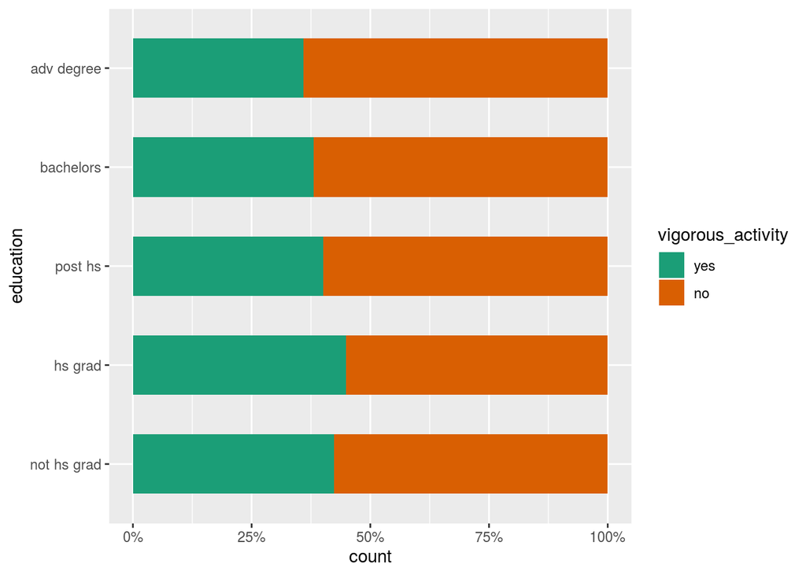

## Inference: Chi Squared Test for Independence

The order of the variables in the `xchisq.test` does not matter in the calculation of the test statistic. They are written this way so the test output matches the earlier table.

```r
xchisq.test(education ~ vigorous_activity , data = act_ed) ### exp ~ resp
```

```
##
##  Pearson's Chi-squared test
##
## data:  x
## X-squared = 13.834, df = 4, p-value = 0.007845
##
##    169      230
## ( 160.46) ( 238.54)
## [0.4546] [0.3058]
## < 0.674> <-0.553>
##
##    374      460
## ( 335.40) ( 498.60)
## [4.4435] [2.9890]
## < 2.108> <-1.729>
##
##    886     1323
## ( 888.36) (1320.64)
## [0.0062] [0.0042]
## <-0.079> < 0.065>
##
##    476      774
## ( 502.69) ( 747.31)
## [1.4172] [0.9533]
## <-1.190> < 0.976>
##
##    150      268
## ( 168.10) ( 249.90)
## [1.9489] [1.3109]
## <-1.396> < 1.145>
##
## key:
##  observed
##  (expected)
##  [contribution to X-squared]
##  <Pearson residual>
```

## Inference: Assessing the largest difference in proportions

From the table and Chi Squared results, the largest difference is between education levels is **hs grad** and **adv degree**. I want to construct a confidence interval to see how big is the difference. So, I will just filter the **hs grad** and **adv degree** levels into a new data frame and then run a `prop.test` for difference in proportions for **no** responses to vigorous activity.

```r
## Testing Difference in Proportion of vigorous activity = "no" between hsgrad and adv degree
prop.test((vigorous_activity == "no") ~ education, data = act_ed2) ## resp ~ exp
```

```
##
##  2-sample test for equality of proportions with continuity correction
##
## data:  tally((vigorous_activity == "no") ~ education)
## X-squared = 8.8189, df = 1, p-value = 0.002981
## alternative hypothesis: two.sided
## 95 percent confidence interval:
##  -0.14842650 -0.03075264
## sample estimates:
##    prop 1    prop 2
## 0.5515588 0.6411483
```

## Narrative Summary

Our largest difference for “no” - vigorous activity was between the educational levels of **hsgrad** at 55% and **adv degree** at 64%. A 95% confidence interval for the true difference is between 3-14%. This difference is statistically significant based on the confidence interval not including zero, as well as the result testing the null hypothesis of “no difference”, yielded a p-value of 0.002981, which is strong enough evidence against the null hypothesis to reject it and make the conclusion that there is a statistical significance difference between the levels for our (population?).

# Part Two : Relationship between 2nd set of categorical variables (`too_tired` vs. `gender`)

## Table and Graphic of `too_tired` vs. `gender`

| gender | never or rarely | sometimes | alot of the time | most of the time or all of the time |
| --- | --- | --- | --- | --- |
| male | 41% (974) | 48% (1134) | 8% (190) | 2% (54) |
| female | 29% (790) | 50% (1369) | 15% (425) | 6% (177) |
| Total | 35% (1764) | 49% (2503) | 12% (615) | 5% (231) |

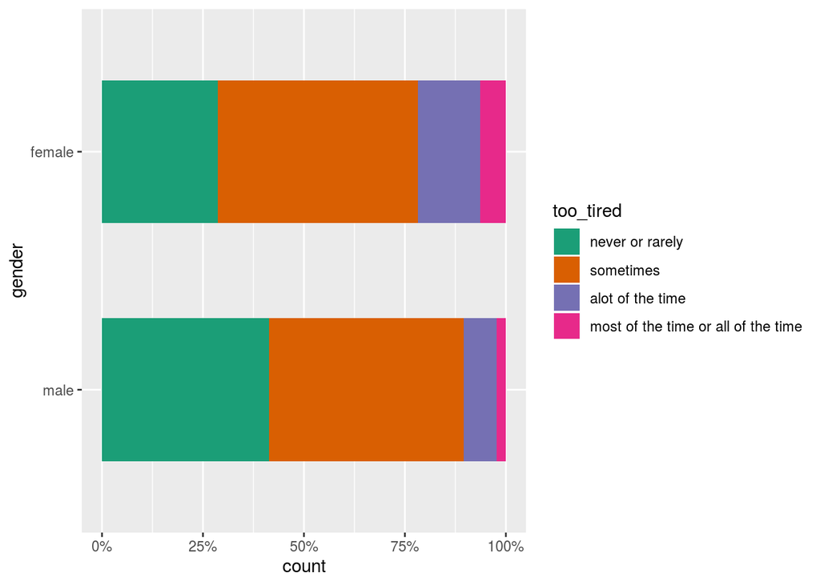

## Inference: Chi Squared Test for Association

```r
xchisq.test( gender ~ too_tired , data = tired_gen)  ## exp ~ resp
```

```
##
##  Pearson's Chi-squared test
##
## data:  x
## X-squared = 164.88, df = 3, p-value < 2.2e-16
##
##    974     1134      190       54
## ( 811.45) (1151.39) ( 282.90) ( 106.26)
## [32.56]  [ 0.26]  [30.51]  [25.70]
## < 5.71>  <-0.51>  <-5.52>  <-5.07>
##
##    790     1369      425      177
## ( 952.55) (1351.61) ( 332.10) ( 124.74)
## [27.74]  [ 0.22]  [25.99]  [21.90]
## <-5.27>  < 0.47>  < 5.10>  < 4.68>
##
## key:
##  observed
##  (expected)
##  [contribution to X-squared]
##  <Pearson residual>
```

## Inference: Assessing the largest difference in proportions

```r
prop.test((too_tired=="most of the time or all of the time") ~ gender, data = tired_gen2)  ## prop.test(response ~ explanatory)
```

```
##
##  2-sample test for equality of proportions with continuity correction
##
## data:  tally((too_tired == "most of the time or all of the time") ~ gender)
## X-squared = 48.901, df = 1, p-value = 2.692e-12
## alternative hypothesis: two.sided
## 95 percent confidence interval:
##  -0.05250135 -0.02979470
## sample estimates:
##     prop 1     prop 2
## 0.02295918 0.06410721
```

## Narrative Summary

# ADDITIONAL IN CLASS EXAMPLE

# Part Two - A : Relationship between 2nd set of categorical variables (`too_tired` vs. `education`)

## Table and Graphic of `too_tired` vs. `education`

| education | never or rarely | sometimes | alot of the time | most of the time or all of the time |
| --- | --- | --- | --- | --- |
| not hs grad | 31% (125) | 50% (201) | 13% (52) | 5% (21) |
| hs grad | 37% (305) | 46% (386) | 13% (105) | 5% (39) |
| post hs | 32% (697) | 51% (1118) | 13% (283) | 5% (112) |
| bachelors | 38% (479) | 48% (596) | 10% (127) | 4% (48) |
| adv degree | 38% (158) | 48% (201) | 11% (48) | 3% (11) |
| Total | 35% (1764) | 49% (2502) | 12% (615) | 5% (231) |

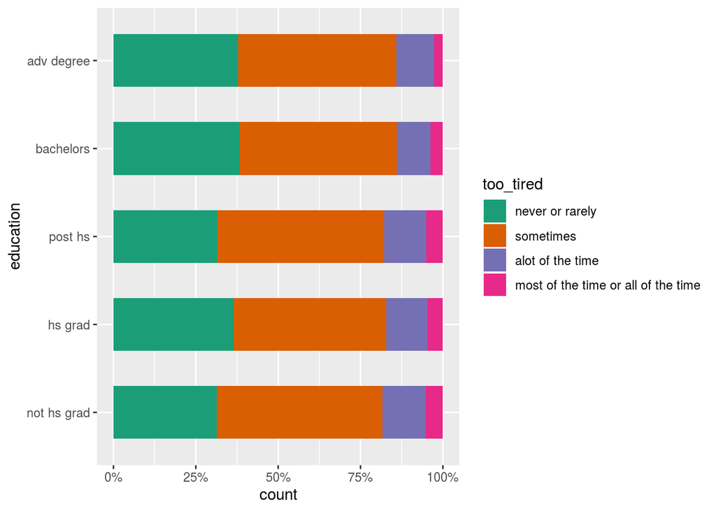

## Inference: Chi Squared Test for Association

```r
xchisq.test( education ~ too_tired , data = tired_educ)  ## exp ~ resp
```

```
##
##  Pearson's Chi-squared test
##
## data:  x
## X-squared = 29.453, df = 12, p-value = 0.003373
##
##    125      201       52       21
## ( 137.68) ( 195.29) (  48.00) (  18.03)
## [1.168]  [0.167]  [0.333]  [0.489]
## <-1.08>  < 0.41>  < 0.58>  < 0.70>
##
##    305      386      105       39
## ( 288.13) ( 408.68) ( 100.45) (  37.73)
## [0.987]  [1.259]  [0.206]  [0.043]
## < 0.99>  <-1.12>  < 0.45>  < 0.21>
##
##    697     1118      283      112
## ( 762.61) (1081.65) ( 265.87) (  99.87)
## [5.644]  [1.221]  [1.103]  [1.475]
## <-2.38>  < 1.11>  < 1.05>  < 1.21>
##
##    479      596      127       48
## ( 431.34) ( 611.80) ( 150.38) (  56.48)
## [5.267]  [0.408]  [3.635]  [1.275]
## < 2.29>  <-0.64>  <-1.91>  <-1.13>
##
##    158      201       48       11
## ( 144.24) ( 204.58) (  50.29) (  18.89)
## [1.313]  [0.063]  [0.104]  [3.295]
## < 1.15>  <-0.25>  <-0.32>  <-1.82>
##
## key:
##  observed
##  (expected)
##  [contribution to X-squared]
##  <Pearson residual>
```

## Inference: Assessing the largest difference in proportions

```r
prop.test((too_tired=="never or rarely") ~ education, data = tired_educ2)  ## prop.test(response ~ explanatory)
```

```
##
##  2-sample test for equality of proportions with continuity correction
##
## data:  tally((too_tired == "never or rarely") ~ education)
## X-squared = 2.989, df = 1, p-value = 0.08383
## alternative hypothesis: two.sided
## 95 percent confidence interval:
##  -0.109855179  0.005882672
## sample estimates:
##    prop 1    prop 2
## 0.3132832 0.3652695
```

## Narrative Summary

# Part Three: Group by a Third Categorical Variable - `vigorous_activity` vs. `education` vs. `gender`

## Graphic of Breakdown by Gender

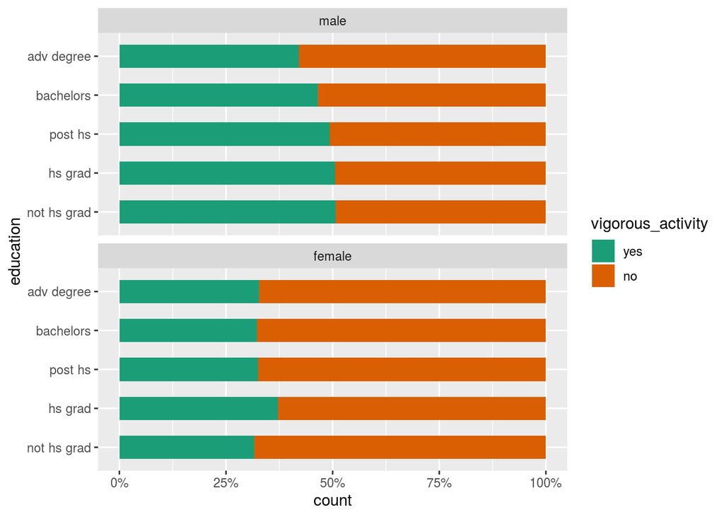

## Table for Males

| education | MALE RESPONSES vigorous activity yes | MALE RESPONSES vigorous activity no |
| --- | --- | --- |
| not hs grad | 51% | 49% |
| hs grad | 51% | 49% |
| post hs | 49% | 51% |
| bachelors | 46% | 54% |
| adv degree | 42% | 58% |
| Total | 49% | 51% |

## Inference: Chi Squared Test for Association (for Males only)

```r
xchisq.test( education ~ vigorous_activity , data = act_ed_M)
```

```
##
##  Pearson's Chi-squared test
##
## data:  x
## X-squared = 4.6315, df = 4, p-value = 0.3272
##
##   114      111
## (109.53) (115.47)
## [0.182]  [0.173]
## < 0.43>  <-0.42>
##
##   241      235
## (231.72) (244.28)
## [0.372]  [0.352]
## < 0.61>  <-0.59>
##
##   491      504
## (484.37) (510.63)
## [0.091]  [0.086]
## < 0.30>  <-0.29>
##
##   239      275
## (250.22) (263.78)
## [0.503]  [0.477]
## <-0.71>  < 0.69>
##
##    59       81
## ( 68.15) ( 71.85)
## [1.229]  [1.166]
## <-1.11>  < 1.08>
##
## key:
##  observed
##  (expected)
##  [contribution to X-squared]
##  <Pearson residual>
```

## Table for Women

| education | FEMALE RESPONSES vigorous activity yes | FEMALE RESPONSES vigorous activity no |
| --- | --- | --- |
| not hs grad | 32% | 68% |
| hs grad | 37% | 63% |
| post hs | 33% | 67% |
| bachelors | 32% | 68% |
| adv degree | 33% | 67% |
| Total | 33% | 67% |

## Inference: Chi Squared Test for Association (for Females only)

```r
xchisq.test( education ~ vigorous_activity , data = act_ed_F)
```

```
##
##  Pearson's Chi-squared test
##
## data:  x
## X-squared = 3.2806, df = 4, p-value = 0.512
##
##    55      119
## ( 57.43) (116.57)
## [0.1030] [0.0508]
## <-0.321> < 0.225>
##
##   133      225
## (118.17) (239.83)
## [1.8622] [0.9175]
## < 1.365> <-0.958>
##
##   395      819
## (400.71) (813.29)
## [0.0813] [0.0401]
## <-0.285> < 0.200>
##
##   237      499
## (242.93) (493.07)
## [0.1449] [0.0714]
## <-0.381> < 0.267>
##
##    91      187
## ( 91.76) (186.24)
## [0.0063] [0.0031]
## <-0.079> < 0.056>
##
## key:
##  observed
##  (expected)
##  [contribution to X-squared]
##  <Pearson residual>
```